# Revenue Analysis

S. 2

Laurens

May 30, 2025

# Data overview

```
## Rows: 336
## Columns: 4
## $ assembly     <chr> "WA", "WA", "WA", "WA", "WA", "WA", "WA", "WA", "WA", "WA…
## $ revenue_item <chr> "Property Rates", "Property Rates", "Property Rates", "Pr…
## $ year         <dbl> 2018, 2019, 2020, 2021, 2022, 2023, 2024, 2018, 2019, 202…
## $ growth_rate  <dbl> 0.0, 0.0, 0.0, -100.0, 0.0, 2418.6, 135.5, 0.0, 65.0, 0.0…
```

```
##    assembly         revenue_item            year       growth_rate
##  Length:336         Length:336         Min.   :2018   Min.   : -100.00
##  Class :character   Class :character   1st Qu.:2019   1st Qu.:  -12.97
##  Mode  :character   Mode  :character   Median :2021   Median :    0.00
##                                        Mean   :2021   Mean   :  454.03
##                                        3rd Qu.:2023   3rd Qu.:   33.33
##                                        Max.   :2024   Max.   :66911.20
##                                                       NA's   :2
```

```
## # A tibble: 10 × 4
##    assembly revenue_item    year growth_rate
##    <chr>    <chr>          <dbl>       <dbl>
##  1 WA       Property Rates  2018          0
##  2 WA       Property Rates  2019          0
##  3 WA       Property Rates  2020          0
##  4 WA       Property Rates  2021       -100
##  5 WA       Property Rates  2022          0
##  6 WA       Property Rates  2023       2419.
##  7 WA       Property Rates  2024        136.
##  8 WA       Other Rates     2018          0
##  9 WA       Other Rates     2019         65
## 10 WA       Other Rates     2020          0
```

```
## [1] "Property Rates"            "Other Rates"
## [3] "Fees"                      "Fines"
## [5] "Licences"                  "Land (incl Miscellaneous)"
## [7] "Rent"                      "Investment"
```

```
## [1] 2018 2019 2020 2021 2022 2023 2024
```

```
## [1] "WA"            "TAMALE"        "BOLGATANGA"    "YENDI"
## [5] "EAST MAMPRUSI" "WEST GONJA"
```

```
##     Min.  1st Qu.   Median     Mean  3rd Qu.     Max.     NA's
##  -100.00   -12.97     0.00   454.03    33.33 66911.20        2
```

Assembly Distribution

| assembly | n | Proportion |
| --- | --- | --- |
| BOLGATANGA | 56 | 0.167 |
| EAST MAMPRUSI | 56 | 0.167 |
| TAMALE | 56 | 0.167 |
| WA | 56 | 0.167 |
| WEST GONJA | 56 | 0.167 |
| YENDI | 56 | 0.167 |

Revenue Item Distribution

| revenue_item | n | Proportion |
| --- | --- | --- |
| Fees | 42 | 0.125 |
| Fines | 42 | 0.125 |
| Investment | 42 | 0.125 |
| Land (incl Miscellaneous) | 42 | 0.125 |
| Licences | 42 | 0.125 |
| Other Rates | 42 | 0.125 |
| Property Rates | 42 | 0.125 |
| Rent | 42 | 0.125 |

Year Distribution

| year | n | Proportion |
| --- | --- | --- |
| 2018 | 48 | 0.143 |
| 2019 | 48 | 0.143 |
| 2020 | 48 | 0.143 |
| 2021 | 48 | 0.143 |
| 2022 | 48 | 0.143 |
| 2023 | 48 | 0.143 |
| 2024 | 48 | 0.143 |

```
## [1] "Summary of Growth Rate (%)"
```

```
##     Min.  1st Qu.   Median     Mean  3rd Qu.     Max.     NA's
##  -100.00   -12.97     0.00   454.03    33.33 66911.20        2
```

Detailed Summary of Growth Rate (%)

| skim_variable | numeric.mean | numeric.sd | numeric.p0 | numeric.p25 | numeric.p50 | numeric.p75 | numeric.p100 | numeric.hist |
| --- | --- | --- | --- | --- | --- | --- | --- | --- |
| data | 454.03 | 4482.96 | -100 | -12.97 | 0 | 33.33 | 66911.2 | ▇▁▁▁▁ |

Skewness and Kurtosis of Growth Rate

| Skewness | Kurtosis |
| --- | --- |
| 12.7 | 172.73 |

- Observations

56 observations per assembly (16.67%), 42 per revenue item (12.5%), and 48 per year (14.29%).

covering 6 MMDassemblies (WA, Tamale, Bolgatanga, Yendi, East Mamprusi, West Gonja), 8 revenue items (Property Rates, Other Rates, Fees, Fines, Licences, Land (incl Miscellaneous), Rent, Investment), and years 2018–2024

The growth_rate distribution is right-skewed (skewness = 12.7, kurtosis = 172.73), with a median of 0% and a mean of 454.03% driven by extreme outliers (max = 66,911.2%). Most growth rates are modest or negative (1st quartile = -12.97%, min = -100%) The median is a more robust measure for trends.

Fluctuating Temporal Trends: Median growth_rate remains near 0% across 2018–2024, with no clear linear trend but notable peaks in 2023 (WA’s Property Rates).

# Descriptives

Growth Rate by Assembly (%)

| assembly | Mean | Median | SD | Min | Max | N |
| --- | --- | --- | --- | --- | --- | --- |
| BOLGATANGA | 16.26 | 0.0 | 52.78 | -83.6 | 246.7 | 56 |
| EAST MAMPRUSI | 24.98 | 0.0 | 86.13 | -100.0 | 363.2 | 56 |
| TAMALE | 2047.67 | 9.2 | 10602.30 | -100.0 | 66911.2 | 56 |
| WA | 334.57 | 0.0 | 2162.62 | -100.0 | 16047.0 | 56 |
| WEST GONJA | 97.72 | 0.0 | 383.45 | -100.0 | 2432.2 | 56 |
| YENDI | 187.35 | 0.0 | 1121.37 | -100.0 | 8318.7 | 56 |

Growth Rate by Revenue Item (%)

| revenue_item | Mean | Median | SD | Min | Max | N |
| --- | --- | --- | --- | --- | --- | --- |
| Fees | 413.10 | 13.90 | 2472.83 | -99.4 | 16047.0 | 42 |
| Fines | 1081.92 | 0.00 | 6786.65 | -100.0 | 43990.0 | 42 |
| Investment | 199.73 | 0.00 | 1300.56 | -100.0 | 8318.7 | 42 |
| Land (incl Miscellaneous) | 53.65 | 1.45 | 232.41 | -100.0 | 1279.0 | 42 |
| Licences | 29.14 | 14.35 | 60.44 | -78.8 | 221.9 | 42 |
| Other Rates | 1693.70 | 0.00 | 10442.14 | -100.0 | 66911.2 | 42 |
| Property Rates | 108.89 | 0.00 | 446.02 | -100.0 | 2418.6 | 42 |
| Rent | 75.59 | 6.40 | 377.58 | -100.0 | 2432.2 | 42 |

Growth Rate by Year (%)

| year | Mean | Median | SD | Min | Max | N |
| --- | --- | --- | --- | --- | --- | --- |
| 2018 | 43.91 | 0.00 | 196.07 | -78.8 | 1279.0 | 48 |
| 2019 | 192.33 | 0.00 | 1200.12 | -100.0 | 8318.7 | 48 |
| 2020 | 41.45 | 5.85 | 81.83 | -99.4 | 363.2 | 48 |
| 2021 | 376.23 | 0.55 | 2368.13 | -100.0 | 16047.0 | 48 |
| 2022 | 977.92 | 0.00 | 6350.23 | -100.0 | 43990.0 | 48 |
| 2023 | 1479.85 | 3.70 | 9652.40 | -100.0 | 66911.2 | 48 |
| 2024 | 63.29 | 0.00 | 328.16 | -100.0 | 1601.4 | 48 |

| assembly | observations | mean_growth | median_growth | positive_rate | volatility |
| --- | --- | --- | --- | --- | --- |
| TAMALE | 56 | 295.02 | 9.2 | 0.57 | 4.13 |
| WA | 56 | 161.88 | 0.0 | 0.38 | 5.60 |
| YENDI | 56 | 152.67 | 0.0 | 0.41 | 5.67 |
| WEST GONJA | 56 | 97.72 | 0.0 | 0.38 | 3.92 |
| EAST MAMPRUSI | 56 | 24.98 | 0.0 | 0.43 | 3.45 |
| BOLGATANGA | 54 | 16.26 | 0.0 | 0.48 | 3.25 |

| revenue_item | extreme_neg | extreme_pos | avg_growth | stability |
| --- | --- | --- | --- | --- |
| Other Rates | 7 | 8 | 217.23 | -3.11 |
| Fines | 6 | 3 | 186.35 | -3.65 |
| Fees | 2 | 7 | 182.84 | -3.97 |
| Investment | 5 | 2 | 152.35 | -4.66 |
| Property Rates | 4 | 7 | 108.89 | -2.24 |
| Rent | 3 | 4 | 75.59 | -2.62 |
| Land (incl Miscellaneous) | 8 | 6 | 53.65 | -1.35 |
| Licences | 2 | 3 | 29.14 | -0.42 |

| year | growth_25th | growth_median | growth_75th | recovery_rate |
| --- | --- | --- | --- | --- |
| 2018 | 0.00 | 0.00 | 18.97 | 0.33 |
| 2019 | -8.35 | 0.00 | 25.62 | 0.48 |
| 2020 | 0.00 | 5.85 | 82.32 | 0.54 |
| 2021 | -26.60 | 0.55 | 19.30 | 0.50 |
| 2022 | -13.20 | 0.00 | 25.25 | 0.44 |
| 2023 | -7.62 | 3.70 | 52.90 | 0.50 |
| 2024 | -34.80 | 0.00 | 4.18 | 0.29 |

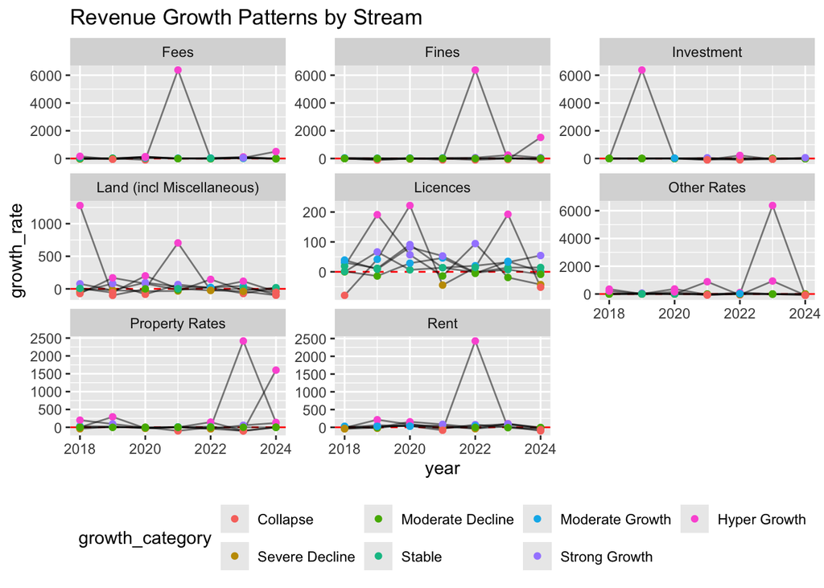

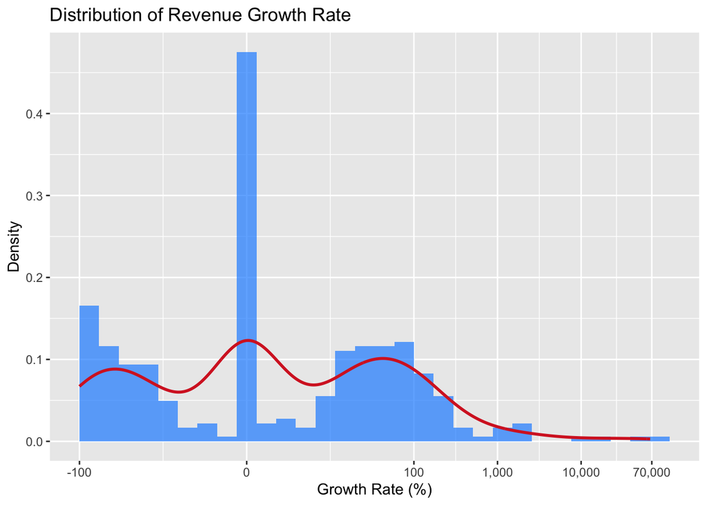

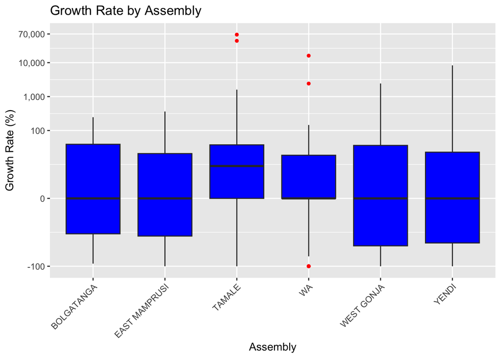

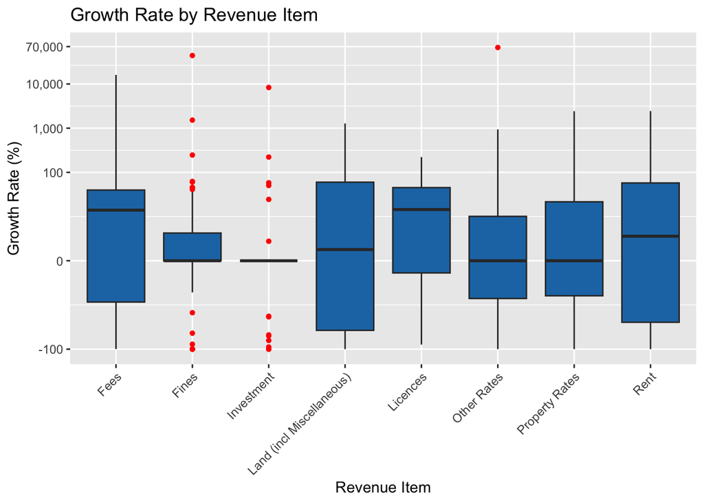

| year | median_growth |
| --- | --- |
| 2018 | 0.00 |
| 2019 | 0.00 |
| 2020 | 5.85 |
| 2021 | 0.55 |
| 2022 | 0.00 |
| 2023 | 3.70 |
| 2024 | 0.00 |

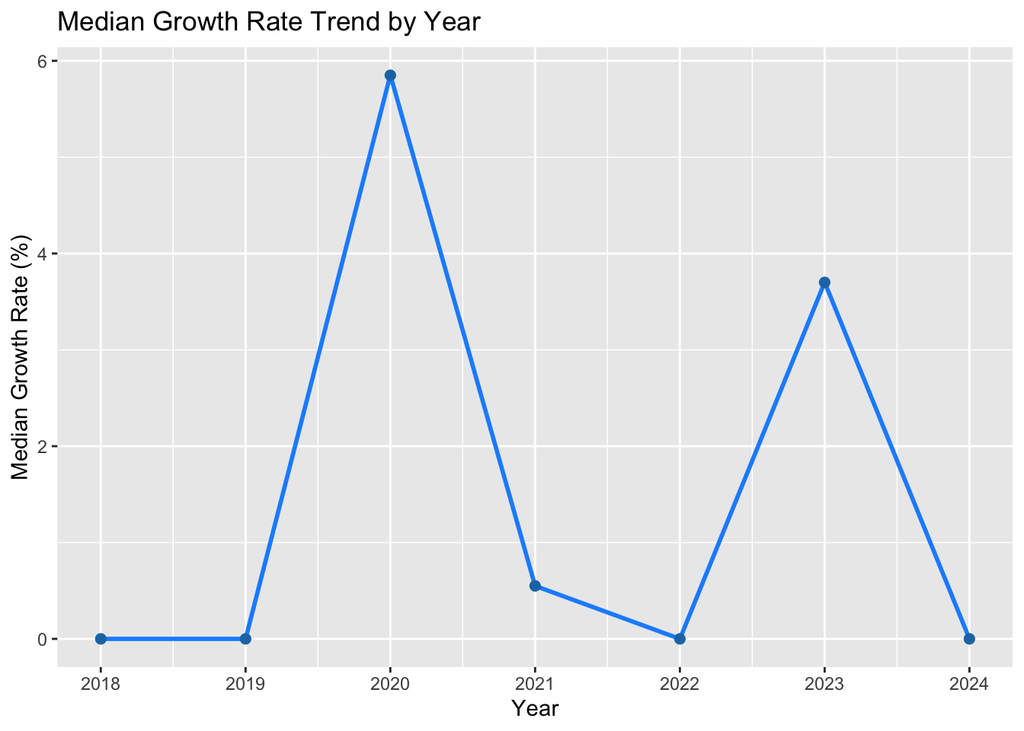

Fluctuating Temporal Trends:

Median growth_rate hovers near 0% (2018–2024), peaking slightly in 2020 (5.85%) and 2023 (3.70%). Mean growth spikes in 2023 (1479.85%, SD = 9652.40%) , with 2022 (977.92%) and 2021 (376.23%) also high. Recovery rates (positive growth) are highest in 2020 (54%) and lowest in 2024 (29%). No consistent linear trend; 2023 shows the highest volatility.

Assembly Disparities: Tamale leads with the highest mean growth (2047.67%, processed mean = 295.02%), but median growth is modest (9.2%). WA (mean = 334.57%, processed = 161.88%) and Yendi (mean = 187.35%, processed = 152.67%) follow, with spikes like WA’s Property Rates (2418.6%, 2023). Bolgatanga (mean = 16.26%) and East Mamprusi (mean = 24.98%) have the lowest growth, with medians at 0%. Volatility is highest in WA (5.60) and Yendi (5.67).

Revenue Item Performance: Other Rates (mean = 1693.70%, processed = 217.23%) and Fines (mean = 1081.92%, processed = 186.35%) show the highest growth. Fees (mean = 413.10%, processed = 182.84%) and Investment (mean = 199.73%) also have high spikes. Licences (mean = 29.14%, median = 14.35%) and Land (incl Miscellaneous) (mean = 53.65%) are more stable but lower. Property Rates (mean = 108.89%, median = 0%) has notable peaks . Rent is moderate (mean = 75.59%). Extreme negatives (≤-50%) are most frequent in Land (8 cases); extreme positives (≥100%) in Other Rates and Fees (8 and 7 cases). Licences are the most stable (stability = -0.42).

High Variability : Box plots show Tamale and WA with the widest ranges, while Bolgatanga and East Mamprusi are tighter.

Visualization:

Line Plots: Median trends show stability (0%) with 2020 and 2023 peaks. Faceted plots by revenue item highlight Property Rates and Other Rates’ 2023 spikes.

Box Plots: Tamale and WA have outliers; Bolgatanga is most consistent. Fines and Other Rates show variability.

Histogram: Pseudo-log scale confirms right-skew, with most growth rates -100% to +100%.

Faceted Growth Patterns: Revenue streams like Other Rates and Fines show sporadic hyper-growth; Licences are steady.

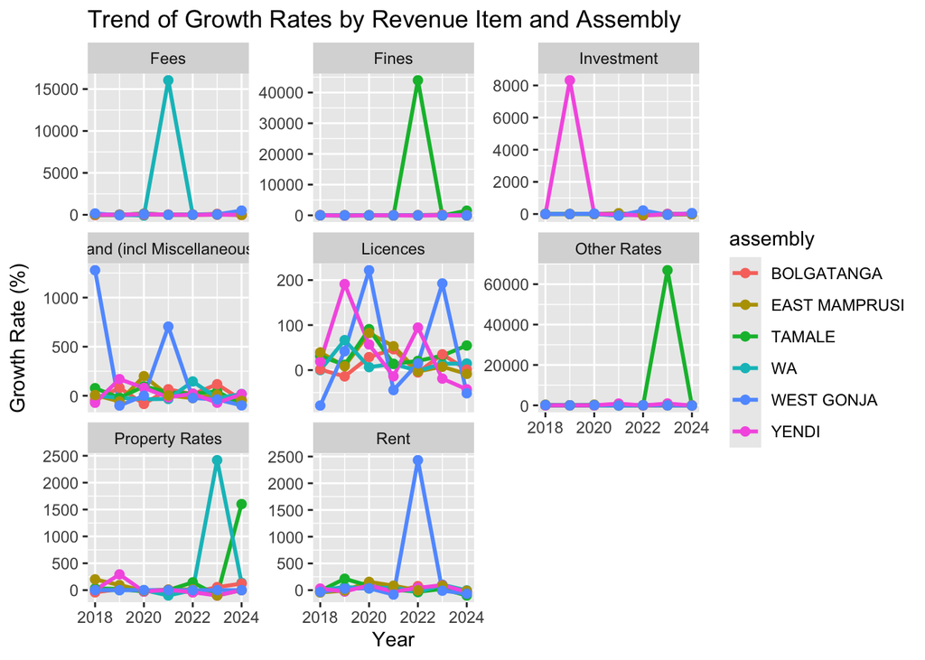

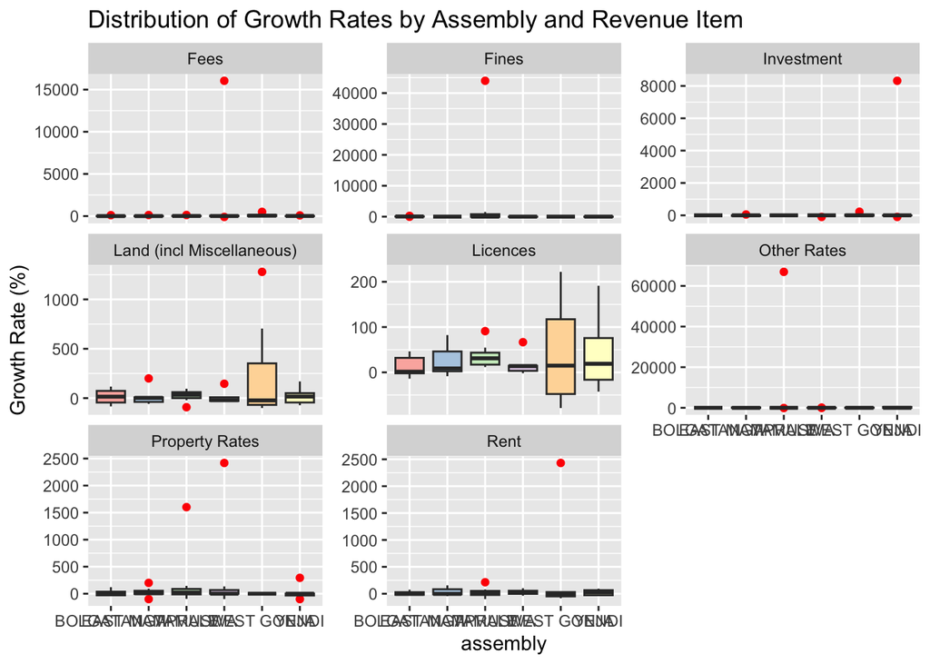

Assemblies with highest average growth

| assembly | avg_growth |
| --- | --- |
| TAMALE | 2047.67 |
| WA | 334.57 |
| YENDI | 187.35 |
| WEST GONJA | 97.72 |
| EAST MAMPRUSI | 24.98 |
| BOLGATANGA | 16.26 |

Revenue with highest average growth

| revenue_item | avg_growth |
| --- | --- |
| Other Rates | 1693.70 |
| Fines | 1081.92 |
| Fees | 413.10 |
| Investment | 199.73 |
| Property Rates | 108.89 |
| Rent | 75.59 |
| Land (incl Miscellaneous) | 53.65 |
| Licences | 29.14 |

Years with highest average growth

| year | avg_growth |
| --- | --- |
| 2023 | 1479.85 |
| 2022 | 977.92 |
| 2021 | 376.23 |
| 2019 | 192.33 |
| 2024 | 63.29 |
| 2018 | 43.91 |
| 2020 | 41.45 |

```
## --- Trend of Median Growth Rate Over Years ---
```

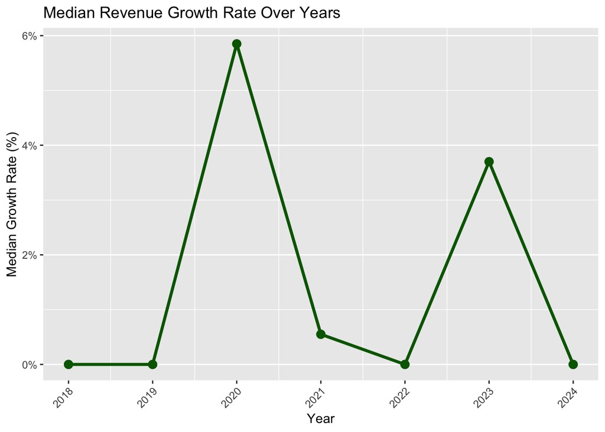

```
## --- Distribution of Growth Rates by Year (Box Plots) ---
```